# Can We Predict the Next MVP Using our own Algorithmic Analysis?

A project by Paul Jojy and Manny Garcia Division of Work: Paul: Part 1, 2, 3, 5  
Manny: Part 4, Outline

# Abstract

Every year, hundreds of NBA players compete for one of the sport's most coveted awards. The NBA Most Valuable Player award. The MVP is given to the one player who contributed the most to their team's success during the regular season. The recipient of this prestigious honor is selected by a committee, who makes the selection based on a number of both objective and subjective factors.

Some of the objective factors that go into the decision process include:

- Points Per Game
- Rebounds Per Game
- Assists Per Game
- Team Wins Some of the Subjective factors include:
- Popularity with Owners
- Popularity with Fans

For more information on the selection process, see here: https://bleacherreport.com/articles/2703746-how-the-nba-mvp-voting-process-works-announcement-date

As you can see, it is difficult to tell who the committee will select, because there are subjective factors that go into selecting the MVP. But what if we could create an algorithm that would predict the next MVP?

# Creating the algorithm

We wanted to create an algorithm that would take into account points, rebounds, steals, turnovers, and assists. However, we wanted also wanted to account for shots made vs. shots missed, because missing a shot hurts the team, making the player less valuable. So, we came up with the formula:

Where

- FGM = Field Goals Made
- FGA = Field Goals Attempted
- FTM = Free Throws Made
- FTA = Free Throws Attempted

We also added multipliers to FGM and FGA. 2 point shots made are multiplied by 2, whereas 3 point shots made are multiplied by 3, because they are worth more points and therefore are more valuable to the team.

There's also a fractional multiplier (.XX) next to the shot attempts. These fractions represent the league average shot percentage for that type of shot. These will be calculated once we have organized the data set. If the league average percentage is higher, then a miss will be penalized more. If the league average is lower, then a miss will be penalized less.

A missed free throw has a negative multiplier because the fact that a player gets to the free throw line is valuable, even if they miss; this is because When a player gets to the free throw line, it is usually because he was fouled. A foul is detrimental to the opposing team and therefore beneficial to the player's team. Furthermore, the game clock is stopped and teammates have a chance to rest and gather themselves, making it a valuable asset, especially in close games.

Turnovers are subtracted because turnovers are detrimental to a team and therefore hurts a player's value to that team.

# Required Tools

The following tools are required to conduct this analysis:

- requests (https://www.geeksforgeeks.org/get-post-requests-using-python/)
- pandas (https://pandas.pydata.org/)
- numpy (http://www.numpy.org/)
- lxml (https://lxml.de/)
- matplotlib.pyplot (https://matplotlib.org/users/pyplot_tutorial.html)
- BeautifulSoup (https://www.crummy.com/software/BeautifulSoup/bs4/doc/)

  # 1. Data Collection: This is the data collection phase of the data lifecycle. In this case, We focus on collecting data from websites. We will be scraping multiple websites for data. Specifically, we will be scraping:

  https://www.basketball-reference.com/awards/awards_2018.html (For Top MVP candidates from years 1997-2018)

  https://www.basketball-reference.com/leagues/NBA_2009_per_game.html (All NBA Players from years 1997- Present)

  The tools in this section will be:
- BeautifulSoup
- requests
- pandas
- lxml

The second website has a different table on a different webpage for each year. However, the only thing that changes in the url is the year. So by creating a for loop that changes the year in the url. We can easily scrape, or gather, the information we need.

```python
#importing required libraries
import re
import requests
from bs4 import BeautifulSoup
import pandas as pd
from lxml import etree
```

Below you can see the variable 'yr' which holds the year. In the for loop, which iterates from 1997-2018, you see yr being used in the url. Afterwards, yr is incremented. We then have the get request to get the information from the url. Then, we use BeautifulSoup to parse the html tags. Next, we used the function 'find' in BeautifulSoup to find all the table tags in the HTML, which could then be parsed to get the information in the table. Finally, this list was appended to an array of the dataframes. A dataframe is like a table that holds data in an organized manner. For more information on dataframes, look here: (https://pandas.pydata.org/pandas-docs/version/0.23.4/generated/pandas.DataFrame.html). For information on any of the other functions mentioned in this blurb, refer to the 'Required Tools' section above.

```python
yr = 1997
MVPCan = []
for i in range(22):
    url = 'https://www.basketball-reference.com/awards/awards_'+str(yr)+'.html'
    yr = yr+1
    html = requests.get(url)
    soup = BeautifulSoup(html.content,'html.parser')
    table = soup.find_all('table')
    df = pd.read_html(str(table))
    MVPCan.append(pd.read_html(str(table)))
MVPCan[3]
```

```
[   Unnamed: 0_level_0             Voting Unnamed: 2_level_0 Per Game Shooting  \
                  Rank             Player                Age       Tm    First
 0                   1   Shaquille O'Neal                 27      LAL    120.0
 1                   2      Kevin Garnett                 23      MIN      0.0
 2                   3    Alonzo Mourning                 29      MIA      0.0
 3                   4        Karl Malone                 36      UTA      0.0
 4                   5         Tim Duncan                 23      SAS      0.0
 5                   6        Gary Payton                 31      SEA      0.0
 6                   7      Allen Iverson                 24      PHI      1.0
 7                   8         Grant Hill                 27      DET      0.0
 8                   9       Chris Webber                 26      SAC      0.0
 9                  10       Vince Carter                 23      TOR      0.0
 10                 11         Jason Kidd                 26      PHO      0.0
 11                 12        Kobe Bryant                 21      LAL      0.0
 12                13T  Darrell Armstrong                 31      ORL      0.0
```

[output cut: 139 more lines]

```python
x = 1997
Players = []
for i in range(23):
    url = 'https://www.basketball-reference.com/leagues/NBA_'+str(x)+'_per_game.html'
    x = x+1
    html = requests.get(url)
    soup = BeautifulSoup(html.content,'html.parser')
    table = soup.find_all('table')
    Players.append(pd.read_html(str(table)))
Players[1][0]
```

|  | Rk | Player | Pos | Age | Tm | G | GS | MP | FG | FGA | ... | FT% | ORB | DRB | TRB | AST | STL | BLK | TOV | PF | PS/G |
| --- | --- | --- | --- | --- | --- | --- | --- | --- | --- | --- | --- | --- | --- | --- | --- | --- | --- | --- | --- | --- | --- |
| 0 | 1 | Mahmoud Abdul-Rauf | PG | 28 | SAC | 31 | 0 | 17.1 | 3.3 | 8.8 | ... | 1.000 | 0.2 | 1.0 | 1.2 | 1.9 | 0.5 | 0.0 | 0.6 | 1.0 | 7.3 |
| 1 | 2 | Tariq Abdul-Wahad | SG | 23 | SAC | 59 | 16 | 16.3 | 2.4 | 6.1 | ... | .672 | 0.7 | 1.2 | 2.0 | 0.9 | 0.6 | 0.2 | 1.1 | 1.4 | 6.4 |
| 2 | 3 | Shareef Abdur-Rahim | SF | 21 | VAN | 82 | 82 | 36.0 | 8.0 | 16.4 | ... | .784 | 2.8 | 4.3 | 7.1 | 2.6 | 1.1 | 0.9 | 3.1 | 2.5 | 22.3 |
| 3 | 4 | Cory Alexander | PG | 24 | TOT | 60 | 22 | 21.6 | 2.9 | 6.7 | ... | .784 | 0.3 | 2.2 | 2.4 | 3.5 | 1.2 | 0.2 | 1.9 | 1.6 | 8.1 |
| 4 | 4 | Cory Alexander | PG | 24 | SAS | 37 | 3 | 13.5 | 1.6 | 3.9 | ... | .676 | 0.2 | 1.1 | 1.3 | 1.9 | 0.7 | 0.1 | 1.3 | 1.4 | 4.5 |
| 5 | 4 | Cory Alexander | PG | 24 | DEN | 23 | 19 | 34.7 | 4.8 | 11.1 | ... | .846 | 0.4 | 3.9 | 4.3 | 6.0 | 2.0 | 0.3 | 2.8 | 2.0 | 14.0 |
| 6 | 5 | Ray Allen* | SG | 22 | MIL | 82 | 82 | 40.1 | 6.9 | 16.0 | ... | .875 | 1.5 | 3.4 | 4.9 | 4.3 | 1.4 | 0.1 | 3.2 | 3.0 | 19.5 |
| 7 | 6 | Derek Anderson | SF | 23 | CLE | 66 | 13 | 27.9 | 3.6 | 8.9 | ... | .873 | 0.8 | 2.0 | 2.8 | 3.4 | 1.3 | 0.2 | 1.9 | 2.1 | 11.7 |
| 8 | 7 | Greg Anderson | C | 33 | ATL | 50 | 0 | 8.0 | 0.7 | 1.6 | ... | .390 | 0.8 | 1.6 | 2.4 | 0.3 | 0.4 | 0.2 | 0.3 | 1.7 | 1.8 |
| 9 | 8 | Kenny Anderson | PG | 27 | TOT | 61 | 56 | 30.5 | 4.4 | 11.0 | ... | .789 | 0.6 | 2.2 | 2.8 | 5.7 | 1.4 | 0.0 | 2.3 | 2.2 | 12.2 |
| 10 | 8 | Kenny Anderson | PG | 27 | POR | 45 | 40 | 32.7 | 4.5 | 11.7 | ... | .772 | 0.8 | 2.2 | 3.0 | 5.4 | 1.4 | 0.0 | 2.5 | 2.2 | 12.6 |
| 11 | 8 | Kenny Anderson | PG | 27 | BOS | 16 | 16 | 24.1 | 4.0 | 9.2 | ... | .837 | 0.2 | 2.3 | 2.4 | 6.3 | 1.6 | 0.0 | 1.8 | 2.3 | 11.2 |
| 12 | 9 | Nick Anderson | SF | 30 | ORL | 58 | 44 | 29.3 | 5.9 | 13.0 | ... | .638 | 1.7 | 3.4 | 5.1 | 2.1 | 1.2 | 0.4 | 1.5 | 1.7 | 15.3 |
| 13 | 10 | Shandon Anderson | SG | 24 | UTA | 82 | 2 | 19.5 | 3.3 | 6.1 | ... | .735 | 1.0 | 1.7 | 2.8 | 1.1 | 0.8 | 0.2 | 1.1 | 1.8 | 8.3 |
| 14 | 11 | Chris Anstey | C | 23 | DAL | 41 | 8 | 16.6 | 2.2 | 5.6 | ... | .716 | 1.3 | 2.5 | 3.8 | 0.9 | 0.8 | 0.7 | 1.0 | 2.3 | 5.9 |
| 15 | 12 | Greg Anthony | PG | 30 | SEA | 80 | 0 | 12.8 | 1.9 | 4.4 | ... | .663 | 0.2 | 1.2 | 1.4 | 2.6 | 0.8 | 0.0 | 1.1 | 1.2 | 5.2 |
| 16 | 13 | B.J. Armstrong | PG | 30 | TOT | 66 | 0 | 12.6 | 1.6 | 3.2 | ... | .840 | 0.2 | 0.9 | 1.2 | 2.3 | 0.4 | 0.0 | 0.6 | 1.1 | 4.0 |
| 17 | 13 | B.J. Armstrong | PG | 30 | GSW | 4 | 0 | 14.8 | 1.5 | 4.8 | ... | .714 | 1.0 | 0.8 | 1.8 | 1.5 | 1.0 | 0.0 | 1.8 | 1.5 | 4.3 |
| 18 | 13 | B.J. Armstrong | PG | 30 | CHH | 62 | 0 | 12.5 | 1.6 | 3.1 | ... | .860 | 0.2 | 0.9 | 1.1 | 2.3 | 0.4 | 0.0 | 0.6 | 1.1 | 3.9 |
| 19 | 14 | Darrell Armstrong | PG | 29 | ORL | 48 | 17 | 25.8 | 3.3 | 7.9 | ... | .854 | 1.4 | 2.0 | 3.3 | 4.9 | 1.2 | 0.1 | 2.3 | 2.0 | 9.2 |
| 20 | 15 | Vincent Askew | SG | 31 | POR | 30 | 5 | 14.8 | 0.6 | 1.8 | ... | .718 | 0.7 | 1.6 | 2.3 | 1.3 | 0.6 | 0.2 | 1.2 | 1.3 | 2.2 |
| 21 | 16 | Keith Askins | SF | 30 | MIA | 46 | 12 | 14.8 | 0.8 | 2.7 | ... | .632 | 0.6 | 1.6 | 2.2 | 0.6 | 0.6 | 0.3 | 0.6 | 2.3 | 2.4 |
| 22 | 17 | Stacey Augmon | SG | 29 | POR | 71 | 23 | 20.4 | 2.2 | 5.2 | ... | .603 | 1.5 | 1.8 | 3.3 | 1.2 | 0.8 | 0.5 | 1.1 | 2.0 | 5.7 |
| 23 | 18 | Isaac Austin | C | 28 | TOT | 78 | 50 | 29.1 | 5.2 | 11.2 | ... | .669 | 2.6 | 4.6 | 7.1 | 2.2 | 0.8 | 0.7 | 2.6 | 3.0 | 13.5 |
| 24 | 18 | Isaac Austin | C | 28 | MIA | 52 | 25 | 26.4 | 4.8 | 10.2 | ... | .680 | 2.3 | 4.1 | 6.3 | 1.7 | 0.8 | 0.7 | 2.3 | 3.1 | 12.7 |
| 25 | 18 | Isaac Austin | C | 28 | LAC | 26 | 25 | 34.4 | 5.9 | 13.0 | ... | .652 | 3.1 | 5.7 | 8.7 | 3.4 | 0.7 | 0.8 | 3.4 | 2.7 | 15.2 |
| 26 | 19 | Vin Baker | C | 26 | SEA | 82 | 82 | 35.9 | 7.7 | 14.2 | ... | .591 | 3.5 | 4.5 | 8.0 | 1.9 | 1.1 | 1.0 | 2.1 | 3.4 | 19.2 |
| 27 | 20 | Charles Barkley* | PF | 34 | HOU | 68 | 41 | 33.0 | 5.3 | 10.9 | ... | .746 | 3.5 | 8.1 | 11.7 | 3.2 | 1.0 | 0.4 | 2.2 | 2.8 | 15.2 |
| 28 | Rk | Player | Pos | Age | Tm | G | GS | MP | FG | FGA | ... | FT% | ORB | DRB | TRB | AST | STL | BLK | TOV | PF | PS/G |
| 29 | 21 | Dana Barros | PG | 30 | BOS | 80 | 15 | 21.1 | 3.5 | 7.6 | ... | .847 | 0.4 | 1.6 | 1.9 | 3.6 | 1.0 | 0.1 | 1.3 | 1.6 | 9.8 |
| ... | ... | ... | ... | ... | ... | ... | ... | ... | ... | ... | ... | ... | ... | ... | ... | ... | ... | ... | ... | ... | ... |
| 538 | 417 | Aaron Williams | PF | 26 | SEA | 65 | 9 | 11.6 | 1.8 | 3.4 | ... | .776 | 0.7 | 1.5 | 2.3 | 0.2 | 0.3 | 0.6 | 0.8 | 1.8 | 4.6 |
| 539 | 418 | Alvin Williams | SG | 23 | TOT | 54 | 13 | 19.8 | 2.3 | 5.2 | ... | .722 | 0.4 | 1.1 | 1.5 | 1.9 | 0.7 | 0.1 | 1.1 | 1.5 | 6.0 |
| 540 | 418 | Alvin Williams | SG | 23 | POR | 41 | 10 | 21.1 | 2.7 | 5.8 | ... | .734 | 0.5 | 1.0 | 1.5 | 2.0 | 0.7 | 0.0 | 1.2 | 1.5 | 6.9 |
| 541 | 418 | Alvin Williams | SG | 23 | TOR | 13 | 3 | 15.9 | 1.2 | 3.4 | ... | .636 | 0.4 | 1.2 | 1.6 | 1.5 | 0.6 | 0.1 | 0.6 | 1.5 | 3.2 |
| 542 | 419 | Brandon Williams | SG | 22 | GSW | 9 | 2 | 15.6 | 1.8 | 5.6 | ... | .500 | 0.4 | 1.2 | 1.7 | 0.3 | 0.7 | 0.3 | 1.0 | 2.0 | 4.1 |
| 543 | 420 | Buck Williams | PF | 37 | NYK | 41 | 6 | 18.0 | 1.8 | 3.6 | ... | .732 | 1.9 | 2.6 | 4.5 | 0.5 | 0.4 | 0.4 | 0.9 | 2.3 | 4.9 |
| 544 | Rk | Player | Pos | Age | Tm | G | GS | MP | FG | FGA | ... | FT% | ORB | DRB | TRB | AST | STL | BLK | TOV | PF | PS/G |
| 545 | 421 | Eric Williams | SF | 25 | DEN | 4 | 4 | 36.3 | 6.0 | 15.3 | ... | .689 | 2.5 | 2.8 | 5.3 | 3.0 | 1.0 | 0.0 | 2.3 | 2.3 | 19.8 |
| 546 | 422 | Herb Williams | PF | 39 | NYK | 27 | 0 | 6.6 | 0.7 | 1.6 | ... | .125 | 0.2 | 0.9 | 1.1 | 0.1 | 0.2 | 0.3 | 0.2 | 1.3 | 1.4 |
| 547 | 423 | Hot Rod Williams | C | 35 | PHO | 71 | 30 | 18.8 | 1.3 | 2.8 | ... | .699 | 1.5 | 2.9 | 4.4 | 0.7 | 0.5 | 0.8 | 0.4 | 1.9 | 3.6 |
| 548 | 424 | Jayson Williams | C | 29 | NJN | 65 | 65 | 36.0 | 4.9 | 9.9 | ... | .666 | 6.8 | 6.8 | 13.6 | 1.0 | 0.7 | 0.8 | 1.5 | 3.6 | 12.9 |
| 549 | 425 | Jerome Williams | PF | 24 | DET | 77 | 3 | 16.9 | 2.0 | 3.7 | ... | .651 | 2.2 | 2.7 | 4.9 | 0.6 | 0.7 | 0.1 | 0.8 | 1.9 | 5.3 |
| 550 | 426 | Lorenzo Williams | PF | 28 | WAS | 14 | 6 | 7.9 | 0.9 | 1.2 | ... | .000 | 1.1 | 0.7 | 1.9 | 0.2 | 0.1 | 0.2 | 0.1 | 1.2 | 1.9 |
| 551 | 427 | Micheal Williams | PG | 31 | MIN | 25 | 0 | 6.4 | 0.6 | 1.9 | ... | .970 | 0.1 | 0.5 | 0.6 | 1.3 | 0.4 | 0.1 | 0.6 | 1.0 | 2.6 |
| 552 | 428 | Monty Williams | SF | 26 | SAS | 72 | 16 | 18.3 | 2.3 | 5.1 | ... | .670 | 0.9 | 1.6 | 2.5 | 1.2 | 0.5 | 0.3 | 1.1 | 1.8 | 6.3 |
| 553 | 429 | Scott Williams | C | 29 | PHI | 58 | 7 | 13.8 | 1.6 | 3.7 | ... | .810 | 1.5 | 2.1 | 3.6 | 0.5 | 0.3 | 0.4 | 0.5 | 2.3 | 4.1 |
| 554 | 430 | Travis Williams | SF | 28 | CHH | 39 | 0 | 9.4 | 1.4 | 3.1 | ... | .522 | 1.4 | 1.0 | 2.4 | 0.5 | 0.5 | 0.1 | 0.8 | 1.4 | 3.5 |
| 555 | 431 | Walt Williams | SF | 27 | TOT | 59 | 17 | 24.9 | 3.6 | 9.2 | ... | .864 | 0.8 | 2.5 | 3.4 | 2.1 | 1.0 | 0.6 | 1.6 | 2.7 | 10.3 |
| 556 | 431 | Walt Williams | SF | 27 | TOR | 28 | 16 | 31.3 | 4.5 | 11.4 | ... | .817 | 1.0 | 3.3 | 4.2 | 2.5 | 1.4 | 0.8 | 1.9 | 3.6 | 12.4 |
| 557 | 431 | Walt Williams | SF | 27 | POR | 31 | 1 | 19.2 | 2.7 | 7.3 | ... | .908 | 0.7 | 1.9 | 2.6 | 1.7 | 0.6 | 0.4 | 1.3 | 2.0 | 8.4 |
| 558 | 432 | Corliss Williamson | SF | 24 | SAC | 79 | 75 | 35.7 | 7.1 | 14.4 | ... | .630 | 2.1 | 3.6 | 5.6 | 2.9 | 1.0 | 0.6 | 2.5 | 3.2 | 17.7 |
| 559 | 433 | Kevin Willis | PF | 35 | HOU | 81 | 74 | 31.2 | 6.6 | 12.9 | ... | .793 | 2.9 | 5.5 | 8.4 | 1.0 | 0.7 | 0.5 | 2.1 | 2.9 | 16.1 |
| 560 | 434 | David Wingate | SG | 34 | SEA | 58 | 2 | 9.4 | 1.1 | 2.4 | ... | .517 | 0.3 | 1.0 | 1.4 | 0.6 | 0.4 | 0.1 | 0.6 | 1.0 | 2.6 |
| 561 | 435 | Dontonio Wingfield | SF | 23 | POR | 3 | 0 | 3.0 | 0.0 | 1.0 | ... | .500 | 0.7 | 0.7 | 1.3 | 0.0 | 0.0 | 0.0 | 0.3 | 0.7 | 0.3 |
| 562 | 436 | Joe Wolf | PF | 33 | DEN | 57 | 8 | 10.9 | 0.7 | 2.1 | ... | .500 | 0.6 | 1.6 | 2.2 | 0.5 | 0.4 | 0.1 | 0.4 | 1.6 | 1.5 |
| 563 | 437 | Lorenzen Wright | C | 22 | LAC | 69 | 38 | 30.0 | 3.5 | 7.9 | ... | .659 | 2.6 | 6.2 | 8.8 | 0.8 | 0.8 | 1.3 | 1.2 | 3.4 | 9.0 |
| 564 | 438 | Sharone Wright | C | 25 | TOR | 7 | 0 | 6.3 | 1.0 | 2.0 | ... | .500 | 0.1 | 1.1 | 1.3 | 0.6 | 0.0 | 0.0 | 0.3 | 1.0 | 2.3 |
| 565 | 439 | George Zidek | C | 24 | TOT | 12 | 0 | 5.3 | 0.6 | 2.4 | ... | .875 | 0.3 | 1.1 | 1.4 | 0.2 | 0.0 | 0.2 | 0.3 | 0.8 | 2.4 |
| 566 | 439 | George Zidek | C | 24 | DEN | 6 | 0 | 7.0 | 0.7 | 2.5 | ... | .833 | 0.7 | 1.5 | 2.2 | 0.2 | 0.0 | 0.3 | 0.5 | 0.8 | 3.0 |
| 567 | 439 | George Zidek | C | 24 | SEA | 6 | 0 | 3.7 | 0.5 | 2.3 | ... | 1.000 | 0.0 | 0.7 | 0.7 | 0.2 | 0.0 | 0.0 | 0.2 | 0.8 | 1.8 |

568 rows × 30 columns

# 2. Data Processing

In the 2nd step of the data lifecycle, we will be tidying our data. The data is not perfect; there will be missing fields, extranneous fields, etc. We as data scientists need to know what to do when we encounter data that does not exactly match our needs. That is where tidying data comes in. Data tidying is the process in which we will modify our data to match our needs. This will include actions such as deleting missing fields, removing extra columns, joining tables, etc.

First, we will trim our MVP Candidates Table to only include the top 5 candidates from each year. Next, we will drop all the uneccessary columns from our Players dataframe. We will achieve this by using the 'drop' function in pandas.

Then, We converted all the columns to floats in order to make calculations easier. We calculated the shooting averages for the whole league in order to apply the multipliers to our formula. We will add a new column to this year's NBA Players dataframe, which we named MVP Calc. This is where we will store the calculations from our algorithm.

```python
for i in range (22):
        MVPCan[i][0] = MVPCan[i][0].drop(MVPCan[i][0].index[5:])
for i in range (len(Players)):
    Players[i][0] = Players[i][0].drop(columns = {'Age','Tm','G','Pos','GS','MP','PF','PS/G','FT%','FG%','eFG%','3P%','2P','2PA','2P%','ORB','DRB'})
Currdf = Players[22][0]

Currdf = Currdf[Currdf.Rk != 'Rk']

Currdf['FG'] = Currdf['FG'].astype(float)
Currdf['FGA'] = Currdf['FGA'].astype(float)
Currdf['3P'] = Currdf['3P'].astype(float)
Currdf['3PA'] = Currdf['3PA'].astype(float)
Currdf['FT'] = Currdf['FT'].astype(float)
Currdf['FTA'] = Currdf['FTA'].astype(float)
Currdf['TRB'] = Currdf['TRB'].astype(float)
Currdf['AST'] = Currdf['AST'].astype(float)
Currdf['STL'] = Currdf['STL'].astype(float)
Currdf['BLK'] = Currdf['BLK'].astype(float)
Currdf['TOV'] = Currdf['TOV'].astype(float)

avg_2fg = Currdf['FG'].sum()/Currdf['FGA'].sum()
avg_3fg = Currdf['3P'].sum()/Currdf['3PA'].sum()
avg_ft = Currdf['FT'].sum()/Currdf['FTA'].sum()

#(2PtFGM∗2)−(2PtFGA∗.XX)+(3PtFGM∗3)−(3PtFGA∗.XX)+(FTM)−(FTA∗−.XX)+Rebounds+Assists+Blocks+Steals−Turnovers
Currdf['MVP Calc'] = (2.0*Currdf['FG'])-(Currdf['FG']*avg_2fg)+(Currdf['3P']*3.0)-(Currdf['3PA']*avg_3fg)
+(Currdf['FT'])-(Currdf['FTA']*-avg_ft)+Currdf['TRB']+Currdf['AST']+Currdf['STL']
+Currdf['BLK']-Currdf['TOV']
Currdf
MVPs = []
Players[0][0]['Player'] = Players[0][0]['Player'].map(lambda x: x.rstrip('*'))
for i in range(len(MVPCan)):
    g = pd.DataFrame()
    for j in range(len(MVPCan[i][0]['Voting']['Player'])):
        P = Players[i][0]
        g = pd.concat([g,(P[P.Player == MVPCan[i][0]['Voting']['Player'].iloc[j]])])

        g['FG'] = g['FG'].astype(float)
        g['FGA'] = g['FGA'].astype(float)
        g['3P'] = g['3P'].astype(float)
        g['3PA'] = g['3PA'].astype(float)
        g['FT'] = g['FT'].astype(float)
        g['FTA'] = g['FTA'].astype(float)
        g['TRB'] = g['TRB'].astype(float)
        g['AST'] = g['AST'].astype(float)
        g['STL'] = g['STL'].astype(float)
        g['BLK'] = g['BLK'].astype(float)
        g['TOV'] = g['TOV'].astype(float)

        g['MVP Calc'] = (2.0*g['FG'])-(g['FG']*avg_2fg)+(g['3P']*3.0)-(g['3PA']*avg_3fg)
        +(g['FT'])-(g['FTA']*-avg_ft)+g['TRB']+g['AST']+g['STL']
        +g['BLK']-g['TOV']
    MVPs.append(g)
MVPs[20]
```

[output not shown]

[output cut: 19 more lines]

[output not shown]

|  | 3P | 3PA | AST | BLK | FG | FGA | FT | FTA | MVP Calc | Player | Rk | STL | TOV | TRB |
| --- | --- | --- | --- | --- | --- | --- | --- | --- | --- | --- | --- | --- | --- | --- |
| 580 | 2.5 | 7.2 | 10.4 | 0.4 | 10.2 | 24.0 | 8.8 | 10.4 | 20.785728 | Russell Westbrook | 458 | 1.6 | 5.4 | 10.7 |
| 218 | 3.2 | 9.3 | 11.2 | 0.5 | 8.3 | 18.9 | 9.2 | 10.9 | 19.214724 | James Harden | 172 | 1.5 | 5.7 | 8.1 |
| 331 | 2.0 | 5.2 | 3.5 | 0.7 | 8.6 | 17.7 | 6.3 | 7.2 | 17.504323 | Kawhi Leonard | 261 | 1.8 | 2.1 | 5.8 |
| 279 | 1.7 | 4.6 | 8.7 | 0.6 | 9.9 | 18.2 | 4.8 | 7.2 | 18.825162 | LeBron James | 220 | 1.2 | 4.1 | 8.6 |
| 537 | 3.2 | 8.5 | 5.9 | 0.2 | 9.0 | 19.4 | 7.8 | 8.5 | 20.576347 | Isaiah Thomas | 424 | 0.9 | 2.8 | 2.7 |

# 3. Exploratory Data Analysis and Data Visualization

In this stage of the lifecycle, we attempt to plot our data in graphs in order to observe potential trends or discover new ones.

Tools:

- matplotlib

```
Text(0.5,1,'Field Goals Made vs. MVP Algorithm')
```

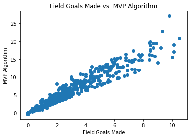

```python
ax1 = plt.scatter(Currdf['FG'],Currdf['MVP Calc'])
plt.xlabel('Field Goals Made')
plt.ylabel('MVP Algorithm')
plt.title('Field Goals Made vs. MVP Algorithm')
```

As you can see, the more field goals a player makes, the higher score the player gets on our MVP algorithm.

```
Text(0.5,1,'3 Pointers Made vs. MVP Algorithm')
```

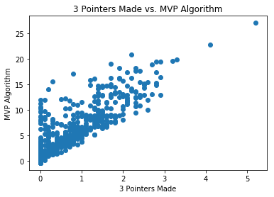

```python
ax1 = plt.scatter(Currdf['3P'],Currdf['MVP Calc'])
plt.xlabel('3 Pointers Made')
plt.ylabel('MVP Algorithm')
plt.title('3 Pointers Made vs. MVP Algorithm')
```

Again, we see that as a player makes more 3 pointers, he scores higher on our algorithm. We also see a major outlier just above the 5 3 pointers made mark. Could be a potential MVP for this year!

```
Text(0.5,1,'Total Rebounds vs. MVP Algorithm')
```

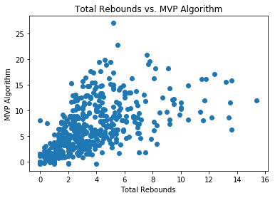

```python
ax1 = plt.scatter(Currdf['TRB'],Currdf['MVP Calc'])
plt.xlabel('Total Rebounds')
plt.ylabel('MVP Algorithm')
plt.title('Total Rebounds vs. MVP Algorithm')
```

```
Text(0.5,1,'Blocks vs. MVP Algorithm')
```

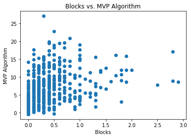

```python
ax1 = plt.scatter(Currdf['BLK'],Currdf['MVP Calc'])
plt.xlabel('Blocks')
plt.ylabel('MVP Algorithm')
plt.title('Blocks vs. MVP Algorithm')
```

This graph seems to be almost horizontal in terms of a correlation line. There is actually an outlier just below the .5 blocks mark. The reason why this player was ranked so high may be because he is a good scorer. Usually players that the team relies on to score, otherwise known as 'guards' are shorter and do not tend to block shots as much as other defensive players would. There is another outlier at the 2.5-3 blocks mark, with the MVP Algorithm rating of about 17. This seems to be a solid all around player (and maybe an MVP).

```
Text(0.5,1,'Steals vs. MVP Algorithm')
```

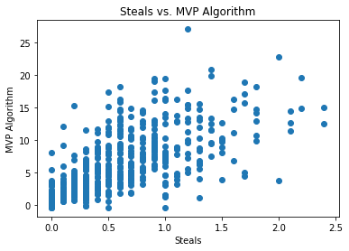

```python
ax1 = plt.scatter(Currdf['STL'],Currdf['MVP Calc'])
plt.xlabel('Steals')
plt.ylabel('MVP Algorithm')
plt.title('Steals vs. MVP Algorithm')
```

There is a very slight upward trend in this graph, similar to that of the Rebounds graph. Overall, We see that defensive traits, such as Rebounding, steals, and blocks, have less of an impact on our MVP algorithm than scoring. However, We believe that teams view players with good offensive skills as more valuable than people with good defensive skills, and the MVP selection committee may agree.

# 4 Machine Learning

# Final Thoughts

This study is important because the MVP race is hotly contested and highly subjective. Removing some of the subjective bias would remove some of the mystery surrounding the potential winner.